# Shallow Water Cape Hake Operating Model Specification

A plausible hypothetical state of nature for investigating the tailored Climate Test.

Tom Carruthers (tom@bluematterscience.com)

2026-11-17

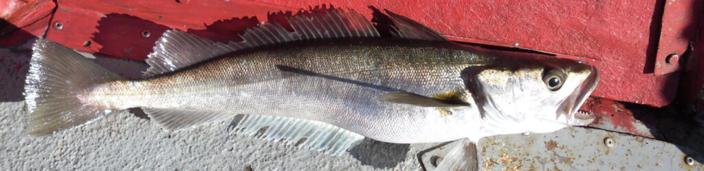

[figure not shown]

# 1 Foreword

This operating model is for conducting exploratory, didactic analyses and is not intended to inform management decision making at this stage. All data used in the construction of these operating models are publicly available from sources that are cited.

# 2 Introduction

This operating model (OM) aims to capture ‘hake-like’ dynamics of a recent reference set of OMs for shallow-water Cape hake, *Merluccius capensis*, by [Ross-Gillespie et al. (2025)](https://zivahub.uct.ac.za/articles/standard/Update_to_the_hake_Reference_Case_Operating_Model_with_inclusion_of_the_2024_commercial_data/30680402/1), for the purposes of testing the robustness of management procedures to projected climate changes originating from an Atlantis Ecosystem Model ([Ortega-Cisneros et al. 2018](https://onlinelibrary.wiley.com/doi/10.1111/fog.12268)).

*M. capensis* is caught off the south and west coasts of South Africa together with the deep-water Cape hake, *M. paradoxus*. The two species are hard to distinguish. Catches are split between them using a species-splitting algorithm (Ross-Gillespie and Butterworth, 2024). Most of the *M. capensis* catch comes from the offshore trawl fleet on both coasts. The remaining catch is taken by the inshore trawl fleet on the south coast, by longline on both coasts and by a south-coast handline fishery. The handline fishery was significant in the early 2000s (up to 7.3 thousand tons in 2001) but has been much reduced since around 2010. Total *M. capensis* catches peaked at about 53 thousand tons in 1985 and have since fluctuated between about 20 and 39 thousand tons, averaging about 28 thousand tons over 2014–2023 (22.5 thousand tons in 2023).

The resource is managed under OMP-2022, a management procedure tested against a Reference Set of nine age-structured, species- and sex-disaggregated operating models. These models are conditioned on commercial catches, GLM-standardised CPUE series, research survey abundance estimates (west coast summer and south coast autumn series from 1985 and 1988 respectively) and catch-at-length and age–length data. The Reference Set spans three stock–recruitment forms (Ricker, and Beverton–Holt with steepness of 0.9 or 0.7) and three central years for the assumed historical catch series (1952, 1958 and 1963). In the 2024 update, the Reference Case model (Ricker, central year 1958) estimates female spawning biomass of 175 thousand tons in 2024. That is 77% of the pristine level and about three times B_MSY. Most of the other Reference Set models also estimate the stock to be well above B_MSY. However, two runs estimate a much more depleted *M. capensis* stock, and the authors note that the data do not determine depletion well (Ross-Gillespie and Butterworth, 2024). The 2025 update of the Reference Case adds the 2024 commercial data (Ross-Gillespie et al., 2025).

The focus of this operating model is capturing the overall stock dynamics in terms of resilience, magnitude and natural variability for the purpose of evaluating under projection, various management procedures (MP) that set annual advice. As such the focus here is not capturing the detailed historical spatial and seasonal dynamics necessary to interpret historical data correctly (a primary challenge for the assessment) but rather to use the assessment estimates for evaluating MPs. For this reason the operating model is sex aggregated (somatic growth and weight at length are very similar among male and female hake in any case). In this Climate Test application we chose to use the Ricker stock-recruitment assumption of Ross-Gillespie and Butterworth (2024) since it provides greater contrast in historical biomass levels and a higher sensitivity to possible climate impacts on stock productivity. The historical catch series used for conditioning was relatively non-impactful and the central ‘1958’ series was used for OM construction in this application.

# 3 Methods

## 3.1 Data Extraction from Conditioned Operating models

Catch data, survey data, growth estimates, weight at length relationships and model estimates of biomass and stock status were digitally extracted from the operating model conditioning reports of Rademeyer et al. (2019), Ross-Gillespie and Butterworth (2024) and Ross-Gillespie et al. (2025):

```r
library(readxl)

xlsx <- "data/M_capensis_hake_extract.xlsx"   # relative to this Rmd

rd <- function(sheet, range, names) {
  df <- as.data.frame(read_excel(xlsx, sheet = sheet, range = range,
                                 col_names = names, na = c("", "-")))
  df[rowSums(!is.na(df)) > 0, , drop = FALSE]   # drop any fully empty rows
}


# 1. M. capensis catches by fleet (thousand t), 1917-2023
#    1917-1977 from the 2019 RC spec (Table App.A.1a); 1978-2023 from the 2024 RS update (Table 1).
#    Blank in source ("-") -> NA. Total columns are the workbook formulas' values.
catches <- rd("Catches_Mcapensis", "A5:K111",
  c("Year", "Offshore_WC", "Offshore_SC", "Inshore_SC", "Longline_WC",
    "Longline_SC", "Handline_SC", "Offshore_total", "Longline_total", "All_total",
    "Source"))

#    Convert to kg (1 thousand t = 1e6 kg) and record missing catches as zero
catch_cols <- setdiff(names(catches), c("Year", "Source"))
catches[catch_cols] <- lapply(catches[catch_cols], function(x) {
  x[is.na(x)] <- 0
  x * 1e6
})

# 2. M. capensis survey biomass and s.e. (thousand t), Table 3b, 1985-2024
survey <- rd("Survey_Mcapensis", "A5:I44",
  c("Year", "WC_Summer", "WC_Summer_se", "WC_Winter", "WC_Winter_se",
    "SC_Spring", "SC_Spring_se", "SC_Autumn", "SC_Autumn_se"))

# 3. Figure 2a panels 11/14/17 (RS02, Ricker, central year 1958), digitized, 1917-2024
#    Bsp_K is NA for 1917-1925 (line hidden behind the panel label).
fig2a <- rd("Fig2a_RS02_digitized", "A5:D112",
  c("Year", "Bsp", "Bsp_K", "Bsp_BMSY"))

#    Cross-check of digitized values against Table 4b
fig2a_check <- rd("Fig2a_RS02_digitized", "A116:D120",
  c("Quantity", "Table4b", "Digitized", "Difference"))

# 4. Figure B.9 M. capensis female length-at-age (RS03 orange curve), digitized
growth_int  <- rd("FigB9_growth_Mcap_F", "A5:B20",  c("Age", "Length_cm"))   # ages 0-15
growth_grid <- rd("FigB9_growth_Mcap_F", "D5:E155", c("Age", "Length_cm"))   # 0.1-yr grid

# 5. Length-weight parameters (2019 RC spec, Table 7). Source: W(g) = alpha * L(cm)^beta.
#    Converted to W(kg) = alpha * L(cm)^beta: since W(kg) = W(g) / 1000, alpha is divided by 1000.
lw_params <- rd("LengthWeight", "A5:D8", c("Species", "Sex", "alpha", "beta"))
lw_params$alpha <- lw_params$alpha / 1000

#    Weight-at-age for M. capensis females from the Figure B.9 lengths
weight_at_age <- rd("LengthWeight", "A13:D28",
  c("Age", "Length_cm", "Weight_g", "Weight_kg"))

# 6. Natural mortality-at-age, ages 0-15 (15 = plus group), 2019 RC spec section 4.1.1
M_at_age <- rd("M_at_age", "A5:C20", c("Age", "M_capensis", "M_paradoxus"))

# 7. Commercial selectivity-at-age by fleet (digitized, Fig B.7b), ages 0-15 in rows,
#    one column per fleet / sex / period (column names taken from the sheet header)
sel_at_age <- as.data.frame(read_excel(xlsx, sheet = "Selectivity_at_age", range = "A4:U20"))

# 8a. Absolute recruitment (millions of fish) for the Ricker models, 1979-2024,
#     digitized from Figure B.2b panel A(ii)
rec_abs <- rd("Recruitment_Ricker", "A5:D50", c("Year", "RS01", "RS02", "RS03"))

# 8b. Stock-recruitment residuals (log space) for the Ricker models, 1985-2023
#    (2024 RS Table B.1a "Zeta"); not estimated (= 0) before 1985
rec_devs <- rd("RecDevs_Ricker", "A5:D43", c("Year", "RS01", "RS02", "RS03"))

# 9. Female maturity: logistic ogive parameters, f(l) = 1/(1+exp((l50-l)/delta)),
#    and approximate M. capensis maturity-at-age from mean length-at-age (ages 0-15)
mat_params <- rd("Maturity", "A5:C6", c("Species", "l50", "delta"))
mat_at_age <- rd("Maturity", "A11:C26", c("Age", "Length_cm", "Mature"))

#    ogive function for any length (cm), M. capensis females
q <- subset(mat_params, Species == "M. capensis")
len2mat <- function(L) 1 / (1 + exp((q$l50 - L) / q$delta))

# Quick checks
str(catches); str(survey); str(fig2a); str(growth_int); str(lw_params)
```

```
#> 'data.frame':    107 obs. of  11 variables:
#>  $ Year          : num  1917 1918 1919 1920 1921 ...
#>  $ Offshore_WC   : num  1000000 1100000 1900000 0 1300000 1000000 2500000 1500000 1900000 1400000 ...
#>  $ Offshore_SC   : num  0 0 0 0 0 0 0 0 0 0 ...
#>  $ Inshore_SC    : num  0 0 0 0 0 0 0 0 0 0 ...
#>  $ Longline_WC   : num  0 0 0 0 0 0 0 0 0 0 ...
#>  $ Longline_SC   : num  0 0 0 0 0 0 0 0 0 0 ...
#>  $ Handline_SC   : num  0 0 0 0 0 0 0 0 0 0 ...
#>  $ Offshore_total: num  1000000 1100000 1900000 0 1300000 1000000 2500000 1500000 1900000 1400000 ...
#>  $ Longline_total: num  0 0 0 0 0 0 0 0 0 0 ...
#>  $ All_total     : num  1000000 1100000 1900000 0 1300000 1000000 2500000 1500000 1900000 1400000 ...
#>  $ Source        : chr  "2019 RC spec, Table App.A.1a" "2019 RC spec, Table App.A.1a" "2019 RC spec, Table App.A.1a" "2019 RC spec, Table App.A.1a" ...
#> 'data.frame':    40 obs. of  9 variables:
#>  $ Year        : num  1985 1986 1987 1988 1989 ...
#>  $ WC_Summer   : num  102.9 113.2 75.4 66.4 NA ...
```

[output cut: 20 more lines]

```r
# Example: convert any length (cm) to weight (kg) for M. capensis females
p <- subset(lw_params, Species == "M. capensis" & Sex == "Female")
len2wt <- function(L) p$alpha * L^p$beta
len2wt(c(30, 50, 70))   # approx. 0.21, 1.0, 2.8 kg
```

```
#> [1] 0.2073313 0.9973549 2.8066835
```

The digitized selectivity curves are expanded to a year x age x fleet array covering the historical period, using the time blocks of Ross-Gillespie and Butterworth (2024). The offshore trawl selectivity changes linearly from the 1977-84 block in 1984 to the 1993+ block in 1993.

```r
years <- 1917:2023
ages  <- sel_at_age$Age          # 0:15
na    <- length(ages)

# fill a year x age matrix from period curves and year breakpoints
build <- function(curves, starts, interp = NULL) {
  # curves: list of age vectors, one per period
  # starts: first year of each period (first element is ignored: covers all earlier years)
  # interp: optional c(y0, y1) - linear change from curve[[k]] at y0 to curve[[k+1]] at y1
  m <- matrix(NA_real_, length(years), na, dimnames = list(years, ages))
  for (i in seq_along(years)) {
    y <- years[i]
    k <- max(1, sum(y >= starts))
    m[i, ] <- curves[[k]]
    if (!is.null(interp) && y > interp[1] && y < interp[2]) {
      w <- (y - interp[1]) / (interp[2] - interp[1])
      k1 <- sum(interp[1] >= starts)              # period in force at y0
      m[i, ] <- (1 - w) * curves[[k1]] + w * curves[[k1 + 1]]
    }
  }
  m / apply(m, 1, max)   # rescale each year so maximum selectivity = 1
}

col <- function(nm) sel_at_age[[nm]]

offshore <- function(coast) {
  build(list(col(paste0(coast, "_offshore_1917-76")),
             col(paste0(coast, "_offshore_1977-84")),
             col(paste0(coast, "_offshore_1993+"))),
        starts = c(1917, 1977, 1993),
        interp = c(1984, 1993))
}

longline <- function(coast, sex) {
  p <- paste0(coast, "_longline_", sex, "_")
  build(list(col(paste0(p, "1984-99")),
             col(paste0(p, "2000-05")),
             col(paste0(p, "2006+"))),
        starts = c(1917, 2000, 2006))
}

constant <- function(nm) build(list(col(nm)), starts = 1917)

sel_list <- list(
  WC_offshore   = offshore("WC"),
  SC_offshore   = offshore("SC"),
  SC_inshore    = constant("SC_inshore"),
  SC_handline   = constant("SC_handline"),
  WC_longline_M = longline("WC", "M"),
  WC_longline_F = longline("WC", "F"),
  SC_longline_M = longline("SC", "M"),
  SC_longline_F = longline("SC", "F")
)

sel_array <- array(unlist(sel_list),
                   dim = c(length(years), na, length(sel_list)),
                   dimnames = list(year = years, age = ages, fleet = names(sel_list)))

# Checks: every year/fleet has max selectivity 1; period 3 offshore curve
# (rescaled) used from 1993; 1988 sits between periods 2 and 3
stopifnot(all(abs(apply(sel_array, c(1, 3), max) - 1) < 1e-12))
p3 <- col("WC_offshore_1993+")
stopifnot(isTRUE(all.equal(unname(sel_list$WC_offshore["2000", ]), p3 / max(p3))))
round(sel_list$WC_offshore[c("1976", "1984", "1988", "1993"), ], 2)
```

```
#>      0 1    2    3 4    5    6    7    8    9   10   11   12   13   14   15
#> 1976 0 0 0.14 0.68 1 0.97 0.90 0.79 0.68 0.60 0.55 0.48 0.43 0.38 0.33 0.29
#> 1984 0 0 0.15 0.71 1 0.96 0.89 0.79 0.67 0.59 0.54 0.47 0.42 0.37 0.32 0.28
#> 1988 0 0 0.13 0.68 1 0.97 0.89 0.80 0.68 0.60 0.54 0.48 0.43 0.38 0.33 0.28
#> 1993 0 0 0.09 0.64 1 0.98 0.90 0.80 0.69 0.61 0.54 0.48 0.43 0.38 0.34 0.29
```

```r
dim(sel_array)   # 107 years x 16 ages x 8 fleets
```

```
#> [1] 107  16   8
```

## 3.3 OM Initialization

```r
library(openMSE)
library(readxl)
packageVersion('MSEtool') # should be v4x
```

```
#> [1] '4.0.0'
```

```r
# Create blank operating model and fill details
om = new('om')
om@Name = "Shallow Water Cape Hake"
om@Longitude = 20.5
om@Latitude  = -35.5
om@Author = 'Tom Carruthers'
om@Agency = 'Blue Matter'
om@Email = 'tom@bluematterscience.com'
om@Region = "South Africa"
om@Sponsor = "The Ocean Foundation"
om@Source = "https://climatetest.bluematterscience.com"

# Basic Config
Years = catches$Year          # historical year labels
ny = length(Years)            # number of historical years
om@nYear = ny                 # historical year
om@pYear = 50                 # 50 projected years
om@Interval = 1               # management updated every 1 year
om@DataLag = 1                # data available from last year (not in-season management)
om@nSim = 48                  # No. realisations of stock and fleet dynamics
om@CurrentYear = max(Years)   # label for most recent historical year
om@Years = Years(om)          # all year labels
om@Seasons = 1                # Annual OM
om@maxF = 3                   # maximum apical exploitation rate is 3.0 (harvest rate of 95%)
om@Seed = 1                   # random seed for stochastic sampling
om@Log[[1]] = paste("OM created:", Sys.Date())
```

## 3.4 Stock and Fleet Initialization

Here the stock and Fleet objects are named.

```r
stock = new('stock')
stock@Name = 'Cape Hake'
stock@CommonName = 'Hake'
stock@Species = 'Merluccius capensis'

FleetIndices = 2:7
nF = length(FleetIndices)
FleetNames = names(catches)[FleetIndices]
fleet_list = list()
ft = 0
for(i in FleetIndices){
  ft = ft+1
  fleet_list[[ft]] = new('fleet')
  fleet_list[[ft]]@Name = FleetNames[ft]
}

print(FleetNames)
```

```
#> [1] "Offshore_WC" "Offshore_SC" "Inshore_SC"  "Longline_WC" "Longline_SC" "Handline_SC"
```

## 3.5 Natural mortality rate

The operating model assumes the same age-dependent natural mortality as the recent operating models.

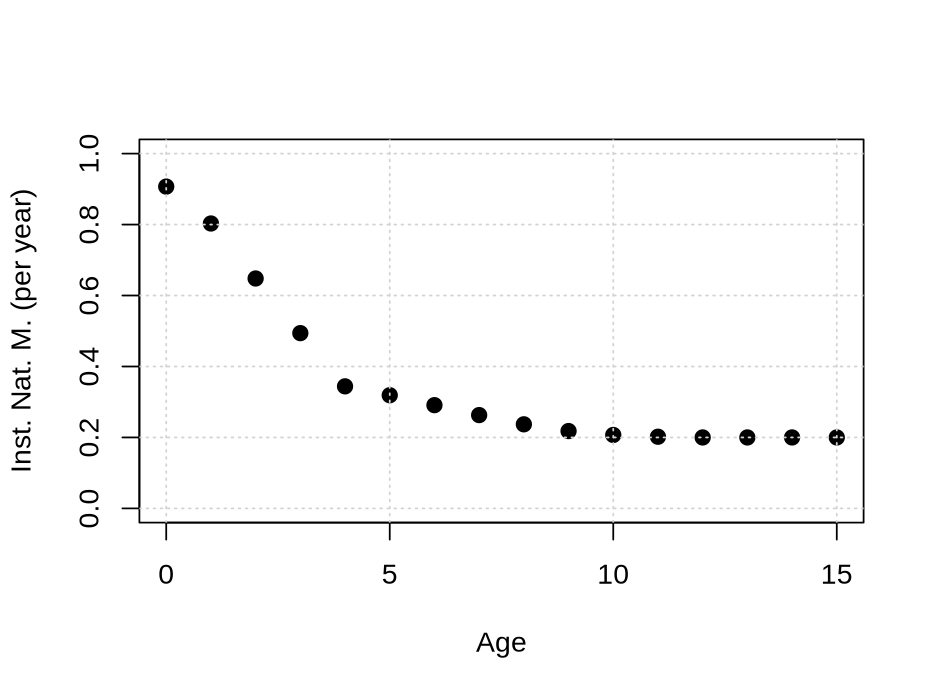

```r
stock@Ages = Ages(nrow(M_at_age)-1, MinAge = min(M_at_age$Age), PlusGroup=TRUE)       # ages 0 to 15+
stock@NaturalMortality = NaturalMortality(MeanAtAge = M_at_age$M_capensis)
plot(stock@Ages@Classes,stock@NaturalMortality@MeanAtAge, pch=19, lwd=2, xlab = "Age", ylim = c(0,1), ylab = "Inst. Nat. M. (per year)"); grid()
```

## 3.6 Somatic Growth

The operating model assumes the female mean length-at-age of the Ricker Reference Set models (RS03 curve of Figure B.9 of Ross-Gillespie and Butterworth 2024, digitized).

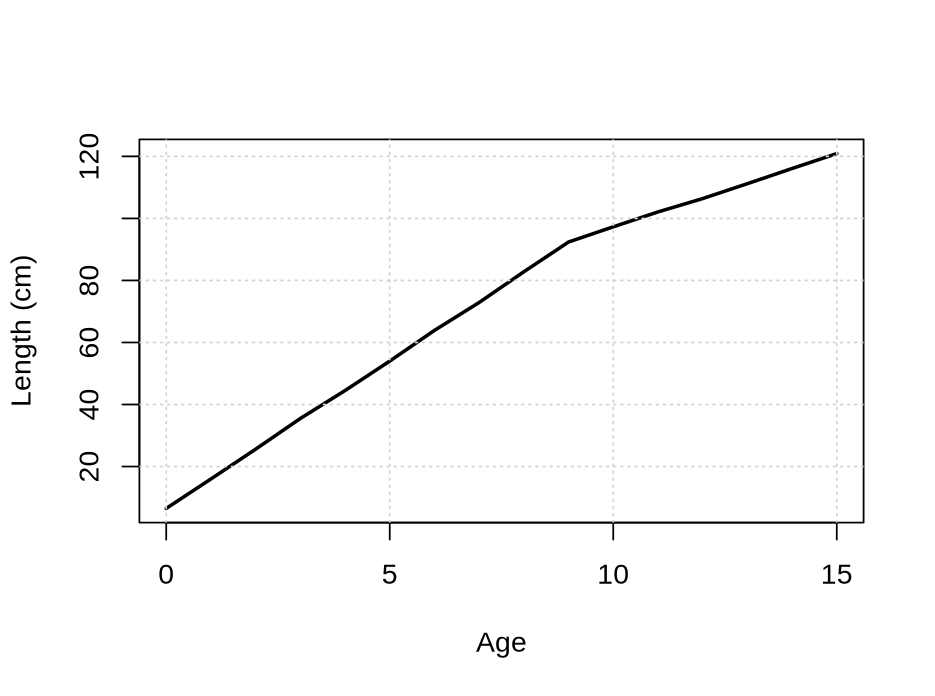

```r
stock@Length = Length(MeanAtAge = growth_int$Length_cm)  # female mean length-at-age, ages 0-15
plot(stock@Ages@Classes,stock@Length@MeanAtAge, lwd=2, type="l",xlab = "Age", ylab = "Length (cm)"); grid()
```

## 3.7 Weight-at-Length

Note that if MP advice is unitless (e.g. catch in the projection relative to catch in 2023) the length-weight relationship is largely inconsequential. To obtain the same scale the length-weight relationship is exactly inversely related to unfished recruitment and numbers are not used in the model.

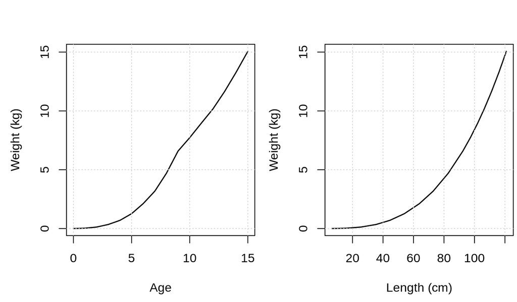

```r
LT =  stock@Length@MeanAtAge
ab = lw_params[lw_params$Species == "M. capensis" & lw_params$Sex == "Female",]
WT =  ab$alpha * LT ^ ab$beta
stock@Weight = Weight(MeanAtAge = WT)
par(mfrow=c(1,2),mai=c(0.9,0.9,0.6,0.05))
plot(stock@Ages@Classes, WT, xlab="Age",ylab = "Weight (kg)",type="l", lwd=1.5); grid()
plot(LT, WT, type="l",lwd=1.5,xlab="Length (cm)",ylab = "Weight (kg)"); grid()
```

## 3.8 Maturity

The maturity ogive follows the female maturity-at-length relationship of the hake Reference Case (Rademeyer et al. 2019, Eq. 45 and Table 6, from Singh et al. 2013). This is a logistic model with a length at 50% maturity of 53.8 cm and a slope parameter of 10.1 cm for *M. capensis*. Maturity-at-age is obtained by applying the ogive to the female mean length-at-age (so it ignores the spread of length at age), with age 0 set to zero as in the Reference Case.

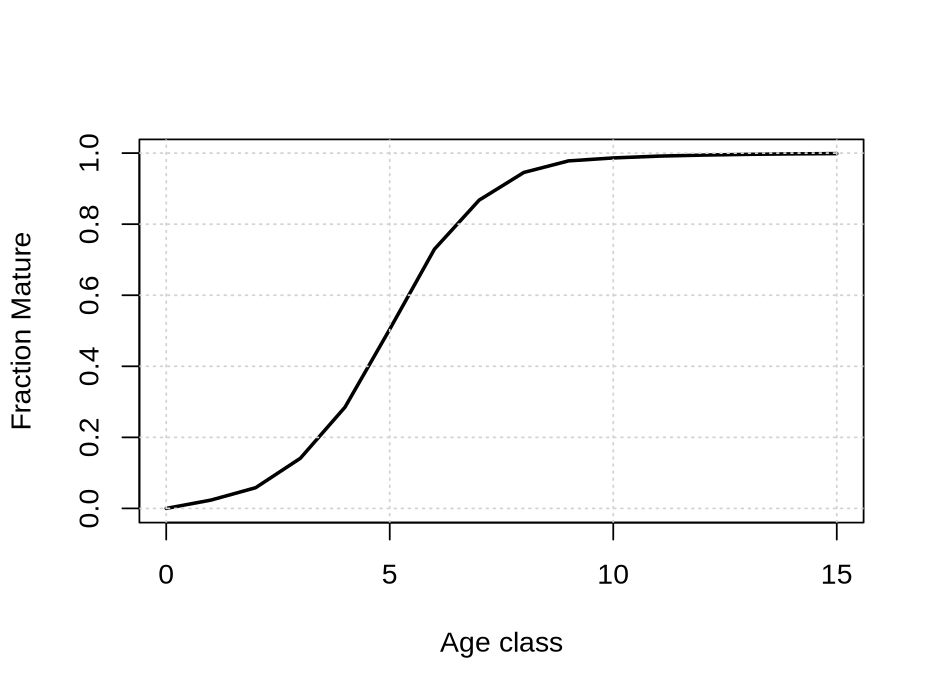

```r
stock@Maturity = Maturity(MeanAtAge = mat_at_age$Mature)
plot( mat_at_age$Age, mat_at_age$Mature, lwd=2, type="l",xlab = "Age class", ylab = "Fraction Mature"); grid()
```

## 3.9 Recruitment

A Ricker stock-recruitment relationship was fitted to the digitized female spawning biomass (Figure 2a) and recruitment (Figure B.2b) of the Reference Case model (RS02) over 1979-2024. The Ricker $\alpha$ and $\beta$ parameters were then converted to unfished recruitment (R0, scale) and Ricker steepness (resilience) using the female unfished spawning biomass per recruit of the operating model.

Historical recruitment deviations are the estimated stock-recruitment residuals of the Reference Case (Table B.1a of Ross-Gillespie and Butterworth 2024, 1985-2023; zero before 1985). The residuals of the two most recent years (2022-2023) are not well informed by data and are replaced by generated values with the same standard deviation and lag-1 autocorrelation, as are those of the projection years.

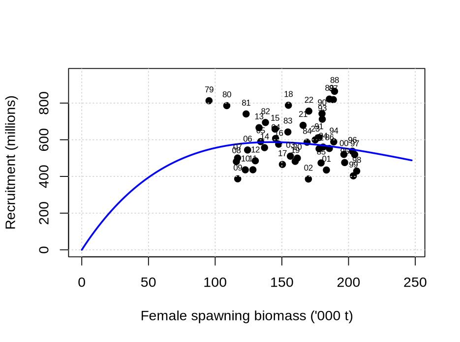

```r
ages = stock@Ages@Classes
nage = length(ages)

recyrs <- match(rec_abs$Year, fig2a$Year)
S <- fig2a$Bsp[recyrs]     # female spawning biomass ('000 t), RS02
R <- rec_abs$RS02          # recruitment (millions), RS02
ok <- !is.na(S) & !is.na(R)
S <- S[ok]; R <- R[ok]; yrs <- rec_abs$Year[ok]

# Linearised Ricker fit: log(R/S) = log(alpha) - beta * S
fit   <- lm(log(R / S) ~ S)
alpha <- exp(coef(fit)[1])
beta  <- -coef(fit)[2]
sigR  <- summary(fit)$sigma            # SD of log-scale residuals


# Derived quantities
Smax <- 1 / beta                       # spawning biomass giving maximum recruitment
Rmax <- alpha / (beta * exp(1))        # maximum (median) recruitment
devs <- residuals(fit)                 # log-space recruitment deviations from the fit

ricker <- function(S) alpha * S * exp(-beta * S)

# Plot data and fitted curve
plot(S, R, xlim = c(0, max(S) * 1.2), ylim = c(0, max(R) * 1.1), pch = 19,
     xlab = "Female spawning biomass ('000 t)", ylab = "Recruitment (millions)");grid()
curve(ricker(x), from = 0, to = max(S) * 1.2, add = TRUE, lwd = 2, col = "blue")
text(S, R, labels = substr(yrs, 3, 4), pos = 3, cex = 0.6)   # year labels
```

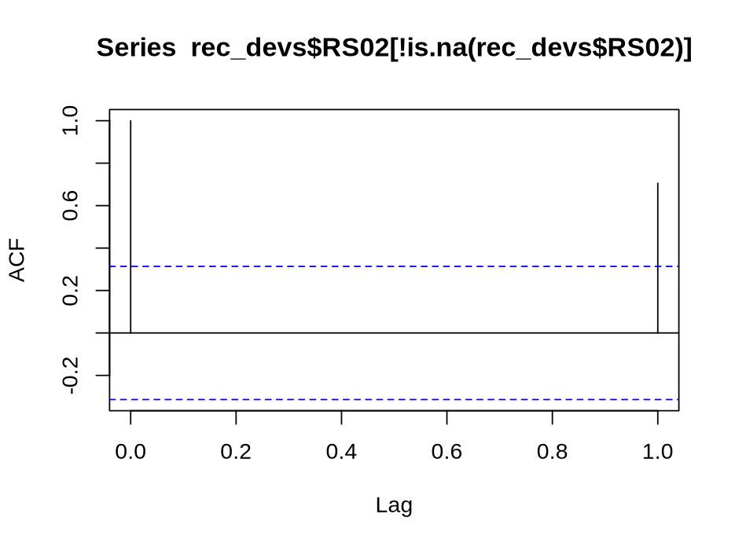

```r
out_alpha_beta = c(alpha = unname(alpha), beta = unname(beta), sigmaR = sigR,
        Smax = unname(Smax), Rmax = unname(Rmax))

# Steepness R0 formulation:
M     <- M_at_age$M_capensis
w_kg  <- len2wt(growth_int$Length_cm)    # female weight-at-age (kg), alpha already /1000
mat   <- mat_at_age$Mature               # female maturity-at-age (approx.)
pfem  <- 0.5                             # assumed female fraction of recruits

surv <- exp(-c(0, cumsum(M[-length(M)])))             # survivorship to start of each age
surv[16] <- surv[16] / (1 - exp(-M[16]))              # age 15 plus group
phi0 <- sum(pfem * surv * w_kg * mat)                 # kg per recruit = '000 t per million recruits

h_hat  <- 0.2 * (alpha * phi0)^0.8
R0_hat <- log(alpha * phi0) / (beta * phi0)
S0_hat <- R0_hat * phi0
outR0_h = c(phi0 = phi0, h = unname(h_hat), R0 = unname(R0_hat), S0 = unname(S0_hat))

# Set up deviations
rdyrs = match(rec_devs$Year, fig2a$Year)
RecDevInit = matrix(1, nrow = om@nSim, ncol = stock@Ages@MaxAge)            # initial rec devs go into year 1 of RecDevHist
RecDevHist = matrix(1 ,nrow = om@nSim, ncol = ny, byrow = T)           # historical rec devs
RecDevHist[,rdyrs] = rep(exp(rec_devs$RS02),each=om@nSim)
RecDevProj = matrix(NA,nrow = om@nSim, ncol = om@pYear)                     # projected rec devs
nterminal = 2                                                               # No. terminal years in need of filling
fyears = rev(rev(om@Years)[1:(nterminal + om@pYear)])                       # labels for years that need filling
AC = acf(rec_devs$RS02[!is.na(rec_devs$RS02)],1)$acf[2,1,1]         # lag-1 recruitment autocorrelation
```

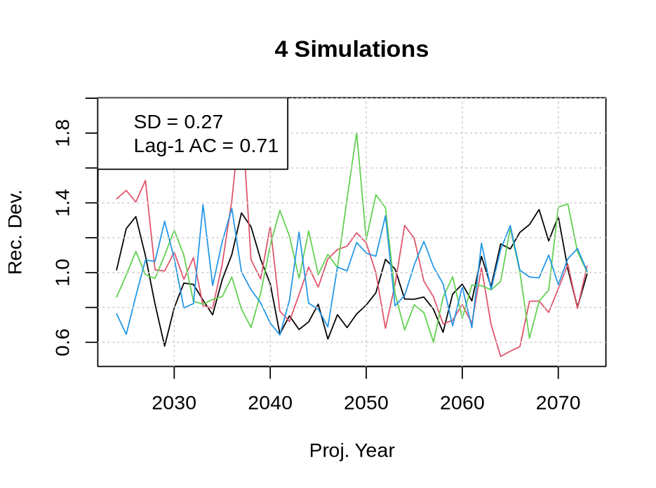

```r
SD = sd(rec_devs$RS02,na.rm=T)
res = MSEtool::GenResiduals(SD, rep(AC,om@nSim), fyears, om@nSim, TruncSD = 3,
                            LastError = RecDevHist[,ny-nterminal])          # generated residuals with AC and SD (LastError is multiplicative)
RecDevHist[,(ny-nterminal+1):ny] = res[,1:nterminal]                        # populate terminal rec devs
RecDevProj = res[, (nterminal+1):ncol(res)]                                 # populate projected rec devs

stock@SRR = SRR(Pars=list(hR=outR0_h[2]), Model = "Ricker", R0 = outR0_h[3] * 1E6, AC = AC, RecDevInit = RecDevInit,  # build Stock Rec. Rel. slot
                RecDevHist = RecDevHist, RecDevProj = RecDevProj)

matplot(Years(om, Period = "P"), t(RecDevProj[1:4,]),lty=1,type="l",
        xlab="Proj. Year",ylab ="Rec. Dev.", main="4 Simulations"); grid()
legend('topleft',legend=c(paste("SD =",round(SD,2)),paste("Lag-1 AC =", round(AC,2))))
```

## 3.10 Selectivity

Selectivities follow the most recent estimates arising from Ross-Gillespie and Butterworth (2024). These are estimated in time blocks for each fleet.

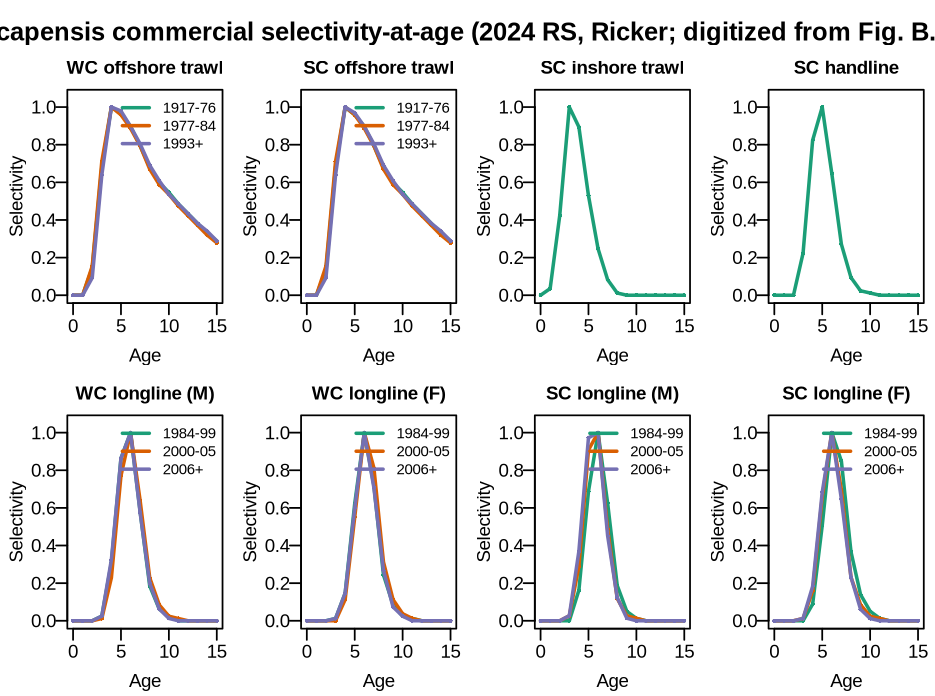

```r
sellookup = c(1,2,3,6,8,4) # the correct indexing for the selectivity array "Offshore_WC" "Offshore_SC" "Inshore_SC"  "Longline_WC" "Longline_SC" "Handline_SC" vs "WC_offshore"   "SC_offshore"   "SC_inshore"    "SC_handline"   "WC_longline_M" "WC_longline_F" "SC_longline_M" "SC_longline_F"
nyear = length(Years(om,"H"))
for(ft in 1:nF){
  flookup = sellookup[ft]
  sAA = aperm(array(rep(sel_array[,,flookup],each=om@nSim),c(om@nSim,nyear,nage)),c(1,3,2))
  fleet_list[[ft]]@Selectivity = Selectivity(MeanAtAge = sAA)
}

# Plot the various selectivities
ages <- sel_at_age$Age
norm <- function(x) x / max(x)

# panel definitions: title and the sel_at_age columns (one per period)
panels <- list(
  "WC offshore trawl" = c("WC_offshore_1917-76", "WC_offshore_1977-84", "WC_offshore_1993+"),
  "SC offshore trawl" = c("SC_offshore_1917-76", "SC_offshore_1977-84", "SC_offshore_1993+"),
  "SC inshore trawl"  = "SC_inshore",
  "SC handline"       = "SC_handline",
  "WC longline (M)"   = c("WC_longline_M_1984-99", "WC_longline_M_2000-05", "WC_longline_M_2006+"),
  "WC longline (F)"   = c("WC_longline_F_1984-99", "WC_longline_F_2000-05", "WC_longline_F_2006+"),
  "SC longline (M)"   = c("SC_longline_M_1984-99", "SC_longline_M_2000-05", "SC_longline_M_2006+"),
  "SC longline (F)"   = c("SC_longline_F_1984-99", "SC_longline_F_2000-05", "SC_longline_F_2006+")
)
cols <- c("#1b9e77", "#d95f02", "#7570b3")   # period 1, 2, 3

op <- par(mfrow = c(2, 4), mar = c(3, 3, 2, 0.5), mgp = c(1.8, 0.5, 0), oma = c(0, 0, 2, 0))
for (nm in names(panels)) {
  cc <- panels[[nm]]
  plot(NA, xlim = range(ages), ylim = c(0, 1.05), xlab = "Age", ylab = "Selectivity",
       main = nm, cex.main = 1, las = 1)
  for (i in seq_along(cc)) {
    lines(ages, norm(sel_at_age[[cc[i]]]), col = cols[i], lwd = 2, type = "o", pch = 16, cex = 0.5)
  }
  if (length(cc) > 1) {
    labs <- sub(".*_", "", cc)   # period label from column name
    legend("topright", legend = labs, col = cols[seq_along(cc)], lwd = 2, bty = "n", cex = 0.8)
  }
}
mtext("M. capensis commercial selectivity-at-age (2024 RS, Ricker; digitized from Fig. B.7b)",
      outer = TRUE, cex = 0.9, font = 2)
```

```r
par(op)
```

The selectivities are remarkably similar among time blocks. Ross-Gillespie and Butterworth (2024) parameterize these such that only the inflection point changes among blocks, the ascending and descending limb parameter of the double normal selectivities are shared among time block for each fleet.

## 3.11 Apical F

The operating model reports provide time series of both catches by fleet and female spawning biomass. These are converted to a guess of apical F by fleet that will be later adjusted to match historical biomass estimates.

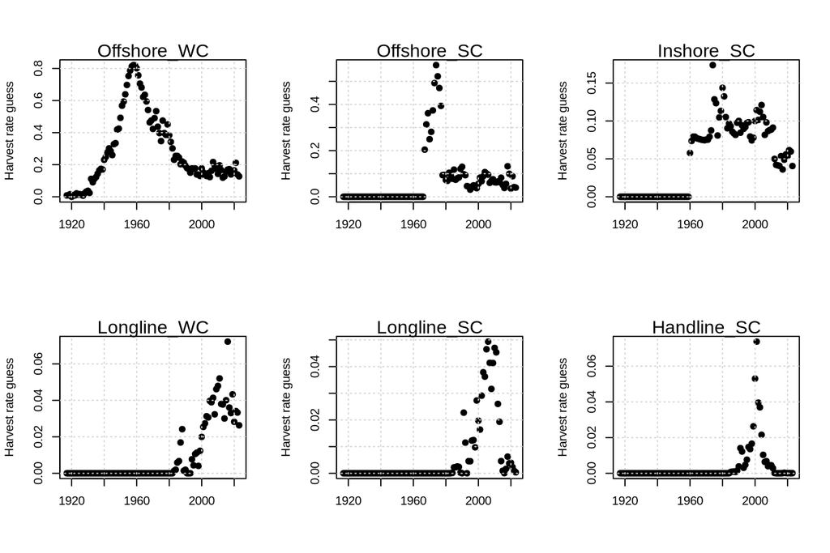

```r
catchyrs = match(catches$Year,fig2a$Year)
Adj_vuln = 2
Adj_sp = 2
par(mfrow=c(2,3))
ft = 0
for(i in FleetIndices){
  U = catches[,i]/(catches[,i]+(fig2a$Bsp[catchyrs]*1E6)/Adj_sp)
  ft = ft+1
  U[is.na(U)|U<1E-5] = 1E-5
  plot(Years, U, pch=19, xlab = "", ylab = "Harvest rate guess"); grid(); mtext(FleetNames[ft])
  F_guess = -log(1-U) / Adj_vuln                            # initial guess of F time series
  F_guess[is.na(F_guess)] = 0
  Eff = matrix(F_guess, nrow=om@nSim, ncol=ny, byrow = T,
             dimnames = list(1:om@nSim,Years(om,'h')))    # Effort matrix with correct year labels
  fleet_list[[ft]]@Effort = Effort(Effort = Eff)                       # Populate historical effort slot
  fleet_list[[ft]]@Catchability = Catchability(Efficiency = 1)
}
```

## 3.12 Initial OM

```r
om@Stock = stock
om@Fleet = fleet_list
hist = Simulate(om)
```

## 3.13 Scale optimization

Two components of the OM specification need to be adjusted to match estimated biomass, recruitment and harvest rate: unfished recruitment (scale), apical F mismatch.

To do this we initialize the OM, calculate female spawning biomass (half the spawning biomass of the sex-aggregated OM) and recruitment, and wrap this into a bivariate optimization for unfished recruitment and apical F modifiers that minimises the absolute log differences from the Reference Case estimates.

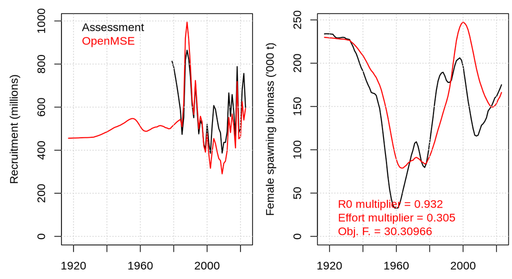

```r
ctrl = SimControl(DynamicUnfished = FALSE,
                  RefLandings = FALSE,
                  RefRemovals = FALSE,
                  ConditionObs = FALSE,
                  EstimateBeta = FALSE,
                  GenerateData = FALSE,
                  MSYRefs = FALSE,
                  RefPoints = FALSE,
                  MGT = FALSE,
                  BLow = FALSE)

B = fig2a$Bsp                  # female spawning biomass ('000 t), 1917-2024
Byrs = fig2a$Year
R = rec_abs$RS02               # recruitment (millions), 1979-2024
Ryrs = rec_abs$Year
HistYrs = Years(om, "H")
Bass = B[match(HistYrs, Byrs)] # assessment estimates aligned to the OM historical years
Rass = R[match(HistYrs, Ryrs)] # (NA where not available)

Apply_pars = function(om, pars){
  R0mult = exp(pars[1])
  Emult = exp(-pars[1]) * exp(pars[2])
  om@Stock@SRR@R0 = om@Stock@SRR@R0 * R0mult
  for(ff in 1:length(om@Fleet)) om@Fleet[[ff]]@Effort@Effort = om@Fleet[[ff]]@Effort@Effort * Emult
  om
}

GetEst = function(om, ctrl){
  hist = Simulate(om, control = ctrl)
  list(B = hist@SBiomass[1,1,] / 2 * 1E-6,       # female spawning biomass ('000 t)
       R = hist@Number[[1]][1,1,,1] * 1E-6)      # recruitment (millions)
}

doplot = function(om, est, pars, obj){
  par(mfrow =c(1,2),mai=c(0.5,0.9,0.2,0.05))
  yrs = Years(om, 'h')
  matplot(yrs, cbind(Rass,est$R), ylab = "Recruitment (millions)", ylim = c(0,max(Rass,est$R,na.rm=T)),col=c("black","red"),lty=1,lwd=1.5,type = 'l');grid()
  legend('topleft',legend=c("Assessment","OpenMSE"),text.col = c("black","red"), bty="n")
  matplot(yrs, cbind(Bass,est$B),ylab="Female spawning biomass ('000 t)", ylim = c(0,max(Bass,est$B,na.rm=T)),col=c("black","red"),lty=1,lwd=1.5,type = 'l');grid()
  legend('bottomleft',legend=c(paste("R0 multiplier =",round(exp(pars[1]),3)),
                            paste("Effort multiplier =",round(exp(-pars[1]) * exp(pars[2]),3)),
                            paste("Obj. F. =", round(obj,5))), text.col = "red", bty="n")
}

Int_Scale = function(pars, om, ctrl){
  est = GetEst(Apply_pars(om, pars), ctrl)
  sum(abs(log(est$B)-log(Bass)),na.rm=T) + sum(abs(log(est$R)-log(Rass)),na.rm=T)
}

opt = optim(c(0,0), Int_Scale,
            om = om, ctrl = ctrl,
            method = "L-BFGS-B", control = list(factr = 1E12, maxit = 10),
            lower = c(-2, -3), upper = c(2, 3))

om2 = Apply_pars(om,opt$par)
doplot(om2, GetEst(om2, ctrl), opt$par, opt$value)
```

## 3.14 Add Generic Observation Model for MP Testing

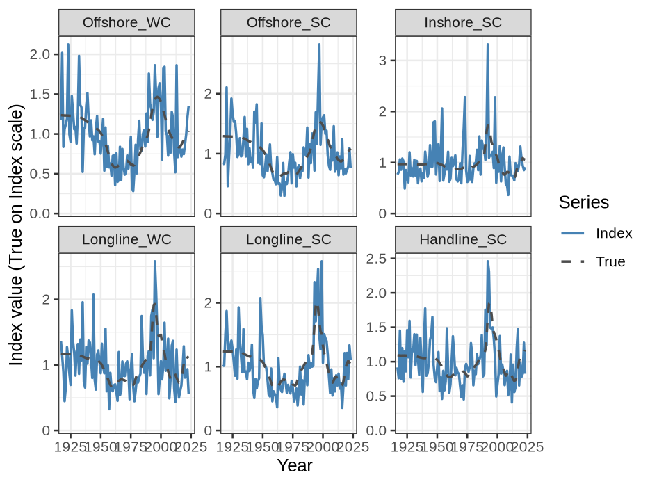

```r
ExampleObs <- Obs(CPUE = IndicesObs(CV = 0.3),                                # CPUE index
                  Survey = IndicesObs(CV = 0.2, Selectivity = 'SBiomass'),    # spawning biomass survey
                  Landings = CatchObs(CV = 0.025))                            # catches

FleetObs <- Obs(CPUE = IndicesObs(CV = 0.3),                                  # other fleets: CPUE and catches only
                Landings = CatchObs(CV = 0.025))

Obs(om2) <- list(c(list(ExampleObs), rep(list(FleetObs), nF - 1)))            # one Obs object per fleet; survey attached to the first fleet

hist <- Simulate(om2)                                                         # historical reconstruction
PlotIndexFit(hist, 'CPUE')                                                    # plot historical CPUE
```

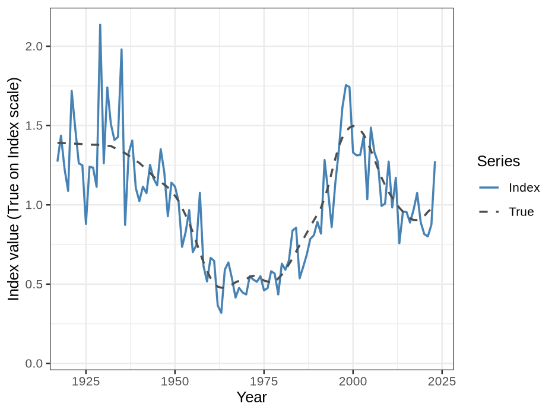

```r
PlotIndexFit(hist, 'Survey')                                                  # plot historical survey
```

```r
# Save outputs to the ClimateTest R package for lazyload
SAH = om2
if(dir.exists("C:/GitHub/ClimateTest/data")) save(SAH, file = "C:/GitHub/ClimateTest/data/SAH.rda")
```

# 4 Results

## 4.1 Assessment Comparison

The operating model of Ross-Gillespie and Butterworth (2024) includes sex structure which this model does not, focusing only on female growth and selectivity.

## 4.2 Example Projections

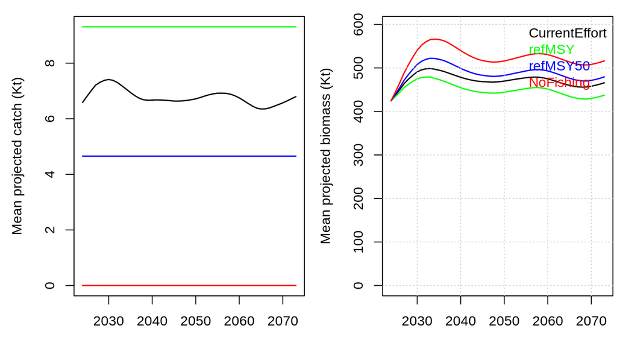

```r
Hist = Simulate(om2)
MPs = c("CurrentEffort","refMSY","refMSY50","NoFishing")
Proj = Project(Hist, MPs)
muC = apply(apply(Proj@Landings, c(1,3,5), sum), c(2,3), mean)   # sum over fleets, then mean over simulations
muB = apply(Proj@Biomass,c(3,4),mean)
mpcols = c("black","green","blue","red")
yrs = Years(om2, 'p')
par(mfrow =c(1,2),mai=c(0.5,0.9,0.2,0.05))
matplot(yrs, muC/1E6,type="l",lty=1, lwd=1.5, ylab="Mean projected catch (Kt)", col = mpcols)
matplot(yrs, muB/1E6,type="l",lty=1, ylim = c(0, max(muB)*1.05/1E6), lwd=1.5, ylab="Mean projected biomass (Kt)", col = mpcols); grid()
legend('topright', legend=MPs, text.col=mpcols, bty="n")
```

# 5 Version Notes

These operating models are subject to ongoing testing and development. If you find a bug or a problem please send a report to tom@bluematterscience.com so that it can be fixed!

# 6 In Development

Outstanding tasks:

[output not shown]

# 7 Background information

Project information, links and results are available from the Climate Test [project webpage](https://blue-matter.github.io/ClimateTest/)

# 8 Software

## 8.1 OpenMSE

The [openMSE R package](https://openmse.com) was used to organize fishery data, define operating models, condition operating models to data, calculate reference points and specify and test existing and alternative management options.

Visit the [OpenMSE website](https://openmse.com) for more information on the framework including tutorial and case studies.

The Rapid Conditioning Model is also [described there](https://openmse.com/tutorial-rcm)

Other useful openMSE apps include [MERA](https://www.merafish.org/) for rapidly scoping operating models and [Reference Point Calculator](https://shiny.bluematterscience.com/app/rpc) for investigating reference points and control rules.

## 8.2 Climate Test

The Climate Test is an extension of OpenMSE that allows for comparative robustness evaluation of candidate management procedures. For more information please visit the [project splash page](https://climatetest.bluematterscience.com)

## 8.3 Management Strategy Evaluation

The Ocean Foundation host the [Harvest Strategies website](https://harveststrategies.org/) which is an excellent resource describing MSE, MSE concepts and how MSE can be used in fishery management including introductory videos and interviews with experts. ‘Harvest strategy’ and Management Procedure are synonymous by the way.

# 9 Climate Test Papers

[Carruthers, T.R.. 2024a. Developing the Climate Test: Robustness Trials for climate-ready management procedures. Col. Vol. Sci. Pap. ICCAT. 81(6): 1-26](https://www.iccat.int/Documents/CVSP/CV081_2024/n_6/CV08106104.pdf)

[Carruthers, T.R., 2024b. Developing the Climate Test: Performance Metrics of Climate Robustness. Col. Vol. Sci. Pap. ICCAT. 81(2): 1-7](https://www.iccat.int/Documents/CVSP/CV081_2024/n_2/CV08102148.pdf)

# 10 References

Hordyk, A., Huynh, Q., Carruthers, T. 2025. OpenMSE: An open-source R package for Management strategy evaluation, available from: https://openmse.com

Ortega-Cisneros, K., Cochrane, K.L., Fulton, E.A., Gorton, R. and Popova, E. 2018. Evaluating the effects of climate change in the southern Benguela upwelling system using the Atlantis modelling framework. Fisheries Oceanography 27: 489-503. https://doi.org/10.1111/fog.12268

Rademeyer, R.A., Butterworth, D.S. and Ross-Gillespie, A. 2019. Specifications of the South African hake 2019 Reference Case assessment. DAFF Branch Fisheries document: FISHERIES/2019/AUG/SWG-DEM/10rev. pdf (The weight-length relationship is given by Eq. 47 and Table 7, values from Singh 2013, FISHERIES/2013/OCT/SWG-DEM/58.)

Ross-Gillespie, A. and Butterworth, D.S. 2024. Conditioning results for the 2024 Hake Reference Set. DFFE Branch Fisheries document: FISHERIES/2024/OCT/SWG-DEM/15rev: 38pp. pdf

Ross-Gillespie, A., Butterworth, D.S. and Maphumalo, T. 2025. Update to the hake Reference Case Operating Model with inclusion of the 2024 commercial data. DFFE Branch Fisheries document: FISHERIES/2025/OCT/SWG-DEM/17: 14pp. (Also IWS/2025/Survey/BG3.) pdf

Singh, L. 2013. FISHERIES/2013/OCT/SWG-DEM/58 (maturity and weight-length parameters, as cited by Rademeyer et al. 2019).

# 11 Acknowledgements

ClimateTest is funded by:

The Paul M. Angell Family Foundation Oceankind The Pew Charitable Trusts

and

The Ocean Foundation in partnership with [www.HarvestStrategies.org](https://harveststrategies.org/)